# Amazon Sales Dashboard 2021-2025

# amazon sales dashboard

Synthetic e-commerce data, 2021-2025 | 81,795 orders | $20.6M revenue | Latest year: 2025

## 1. Sales overview

How much we sell, how fast it grows, and when it happens.

Revenue 2025

$5.4M

+14.2% vs 2024

Orders

21,105

+13.7% vs 2024

Average order value

$256.93

+0.5% vs 2024

Gross margin

35.0%

+-0.0 pp vs 2024

Target achieved

102%

-6.6 pp vs 2024

### Monthly revenue trend

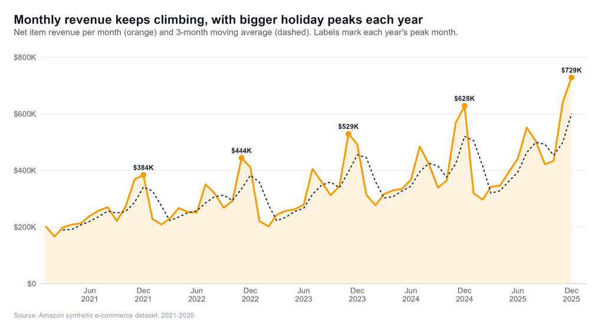

**Results.** Monthly revenue rose from about $203K in January 2021 to a record $729K in December 2025. Each year peaks higher than the one before, and November and December together brought in 25.3% of 2025 revenue. The 3-month average shows that growth continues outside the holiday season too.

### Annual revenue and growth

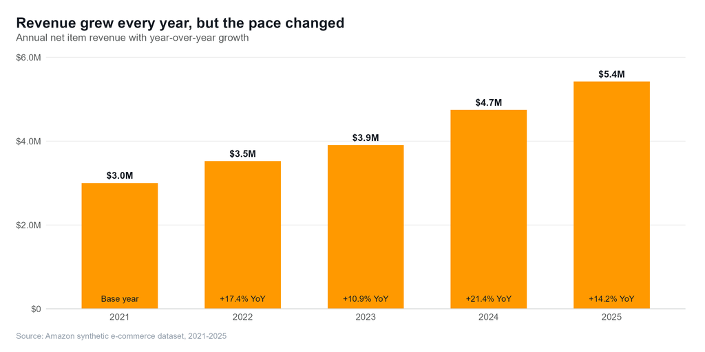

**Results.** Revenue grew from $3.0M in 2021 to $5.4M in 2025, a compound annual growth rate of 15.9%. Growth was uneven. 2024 was the strongest year (+21.4%), and 2023 the weakest (+10.9%), when demand softened in the first half of the year.

### Revenue vs target

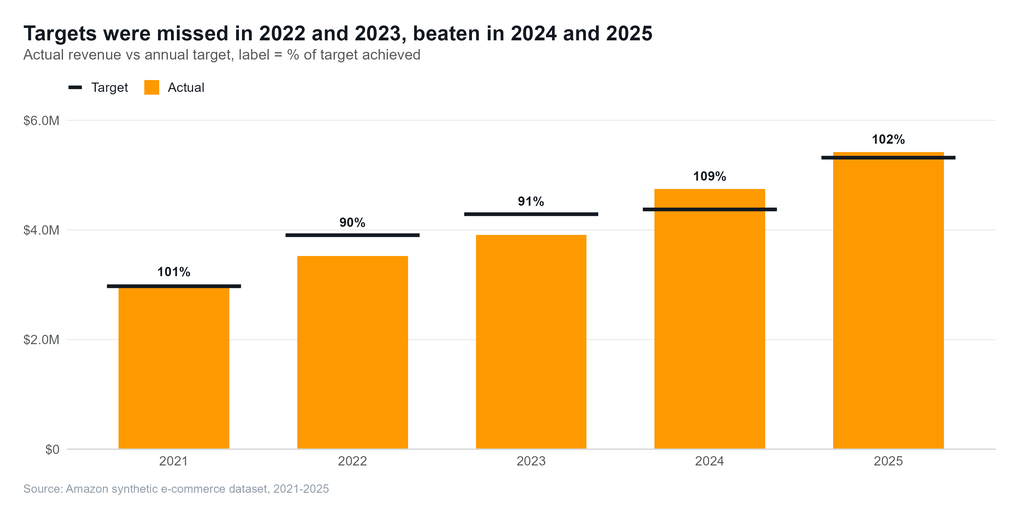

**Results.** The business missed its target in 2022 and 2023 (90% and 91% of plan). In those years targets assumed growth of over 20% that did not happen. Targets were met or beaten in all other years, and 2025 closed at 102% of target.

### Core KPIs by year

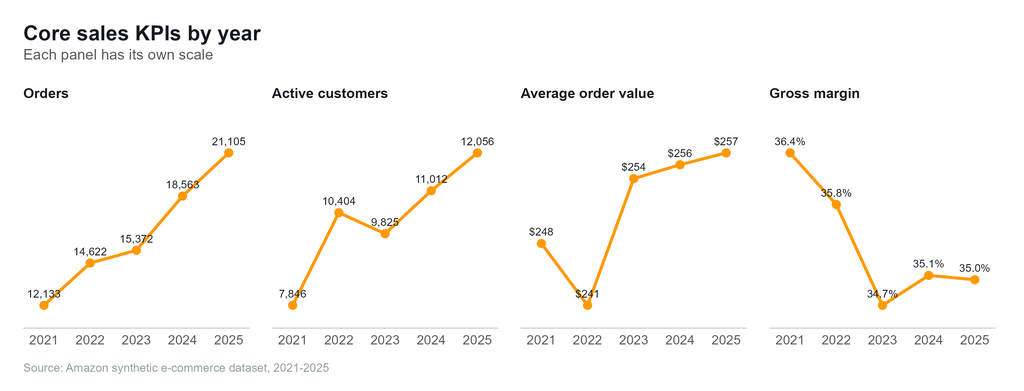

**Results.** Orders grew 74% and active customers 54% over the period. Average order value dipped to $241.12 in 2022, when baskets got smaller as prices rose, then recovered to $256.93. Gross margin slipped 1.4 pp because supplier costs rose slightly faster than selling prices.

### Seasonality

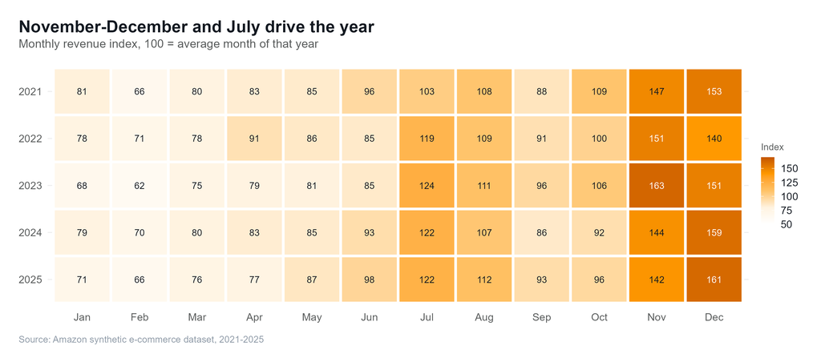

**Results.** December and November are the strongest months (index about 153 and 149), and February is the weakest (about 67). July has become a second peak thanks to Mega Deal Days, which bring 3.3x a normal day’s revenue. Black Friday brings 4.5x.

### Revenue by country

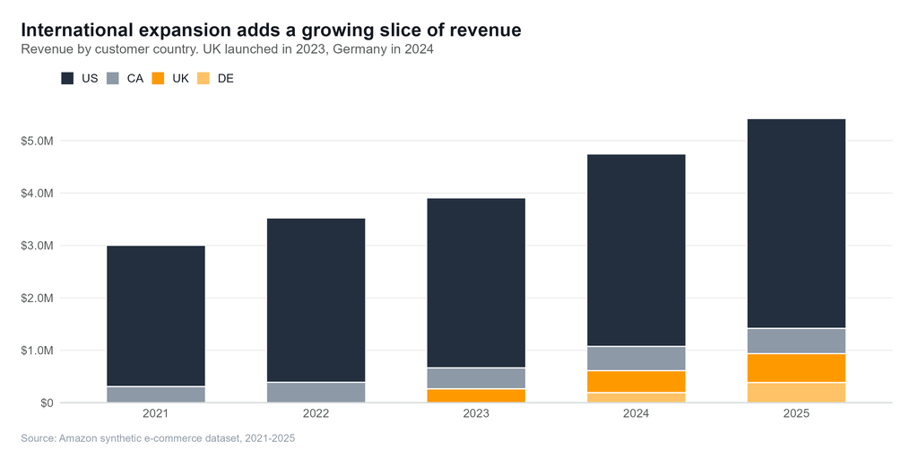

**Results.** Markets outside the US made up 26.1% of revenue in 2025. The UK (launched 2023) reached $552K and Germany (launched 2024) $385K. Expansion added a growth source just as the US market slowed.

## 2. Products & categories

Which categories, products and sellers drive revenue, and how the mix is shifting.

Top category 2025

Electronics

30.0% of revenue

Fastest growing

Grocery

+47.1% vs 2024

Marketplace (3P) share

67.0%

+4.9 pp vs 2021

Commission income

$469K

from 258 sellers

Categories on target

4 of 9

in 2025

### Category mix shift

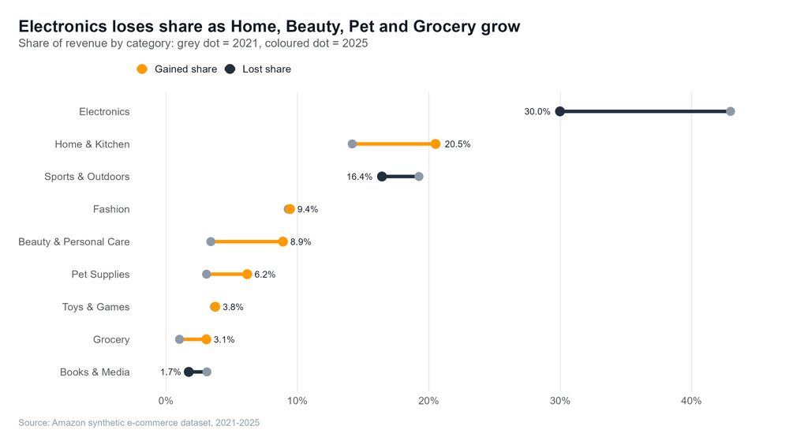

**Results.** Electronics remains the largest category but lost 13.0 pp of share, falling from 43.0% to 30.0%. Home & Kitchen gained the most (+6.3 pp). Beauty, Pet Supplies and Grocery more than doubled their share, which spreads revenue across more everyday, repeat-purchase categories.

### Category growth in 2025

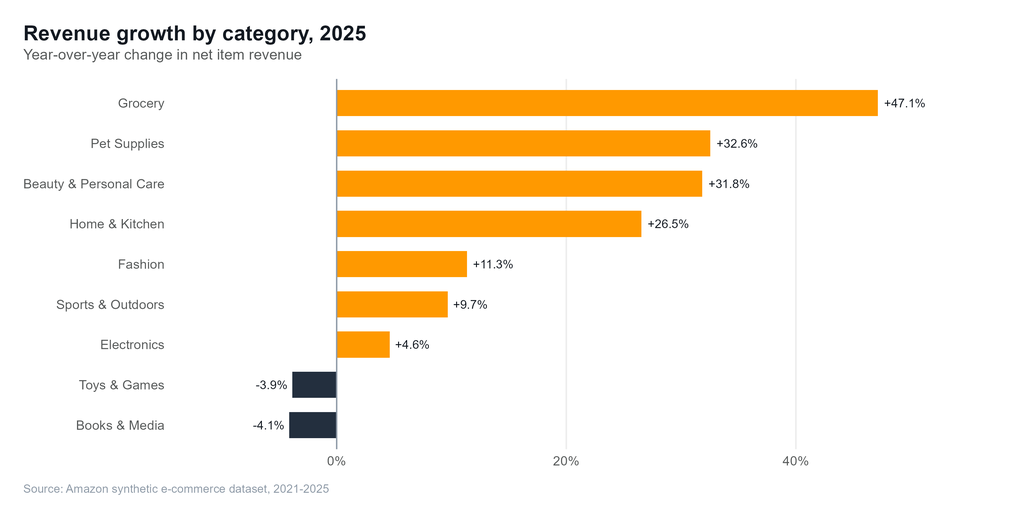

**Results.** Grocery grew fastest in 2025 (+47.1%), followed by the other everyday categories. Books & Media and Toys & Games declined, so these are the categories to review for assortment and pricing.

### Monthly revenue by category

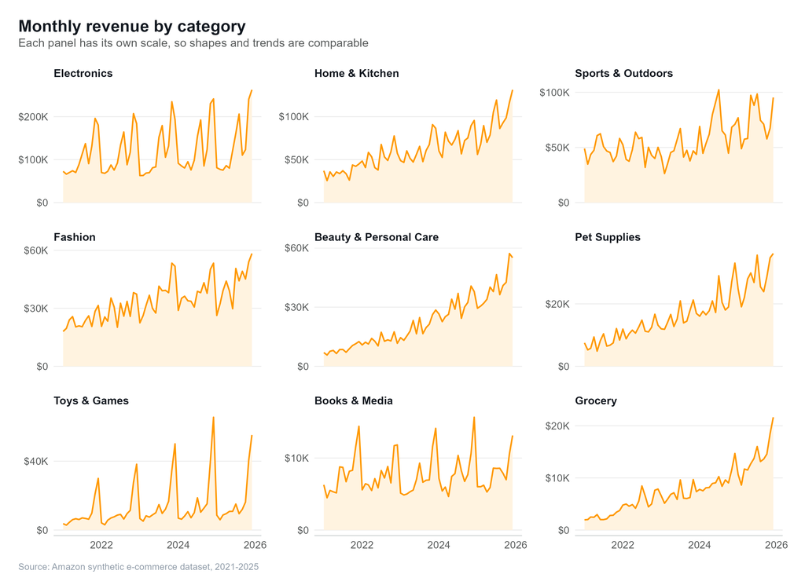

**Results.** The categories follow very different seasonal patterns. Toys & Games and Electronics depend heavily on November-December, and Sports & Outdoors peaks in spring and summer. Beauty, Pet Supplies and Grocery grow steadily all year, which makes them the most predictable revenue.

### Top 10 products

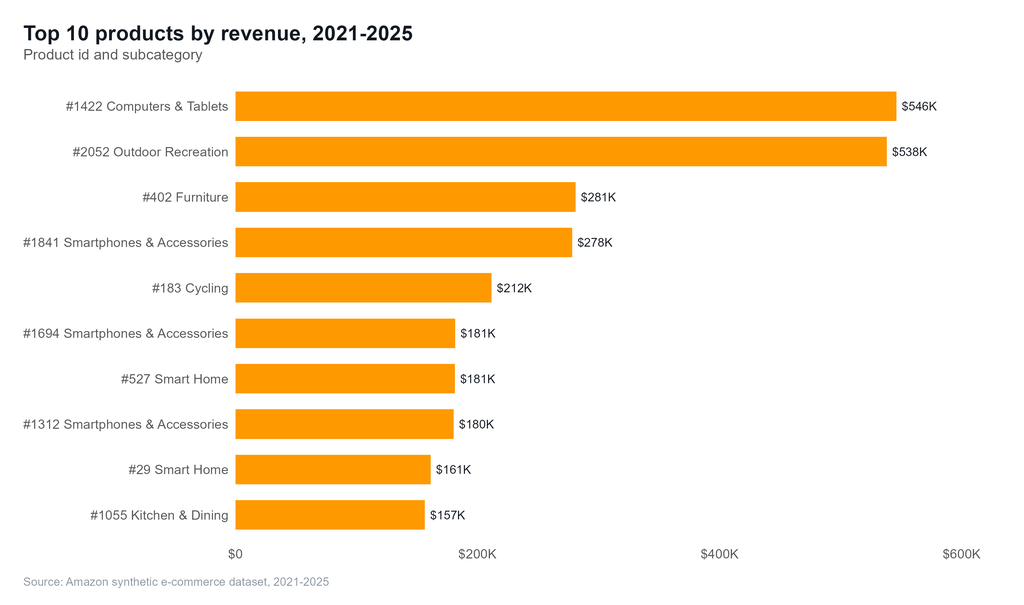

**Results.** The best-selling product (#1422, Computers & Tablets) generated $546K over five years. The top 10 products account for 13.2% of total revenue, and 21% of products generate 80% of revenue. Keeping these products in stock is a priority.

### First-party vs marketplace sellers

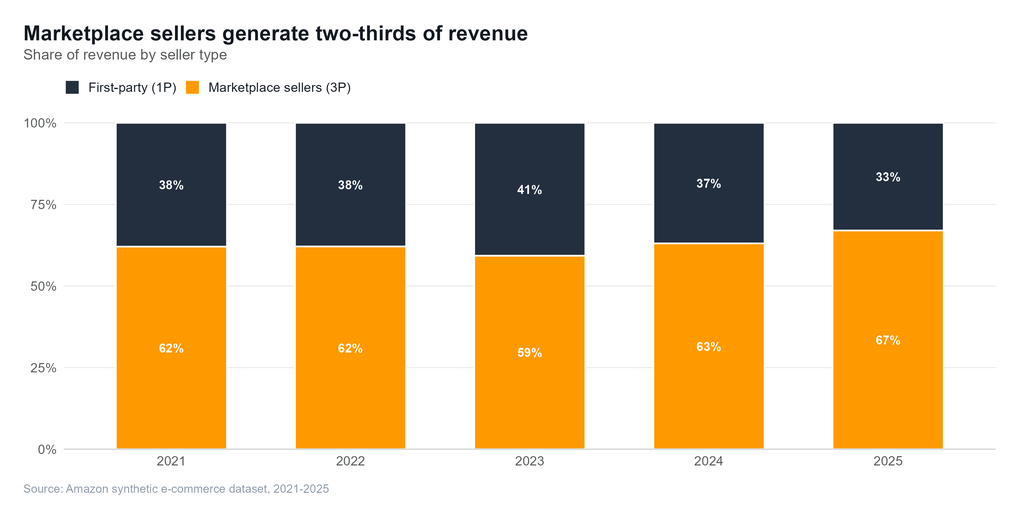

**Results.** Marketplace (3P) sellers generated 67.0% of revenue in 2025, up from 62.1% in 2021. That earned $469K in commission. The number of active 3P sellers grew to 258, so the marketplace is now the main growth engine.

## 3. Customers

Who buys, how often they come back, and which customers are most valuable.

Active customers

12,056

+9.5% vs 2024

Returning-customer orders

65.3%

+5.4 pp vs 2024

Prime share of orders

41.4%

+8.1 pp vs 2024

Orders per customer

1.75

+3.8% vs 2024

New customers

7,330

-1.6% vs 2024

### New vs returning customers

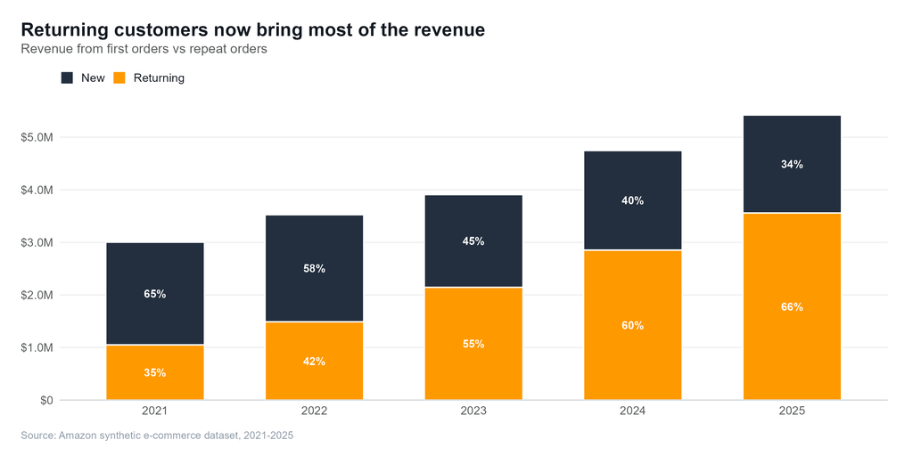

**Results.** In 2021, returning customers placed 35% of orders. By 2025 that rose to 65%. The number of new customers has stayed fairly flat since 2022, at around 7,500 a year, so growth now comes mainly from existing customers buying more often.

### Cohort retention

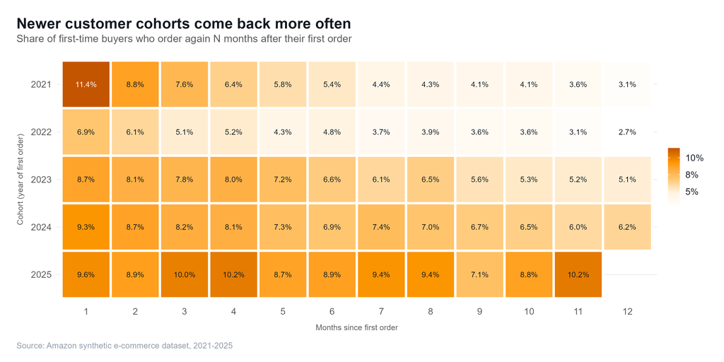

**Results.** The 2022 cohort had the weakest loyalty: only 2.7% were still buying 12 months after their first order, because slow deliveries hurt their first experience. The 2024 cohort reached 6.2% after 12 months, and the 2025 cohort is tracking even higher (9.6% reordered within one month).

### Prime membership

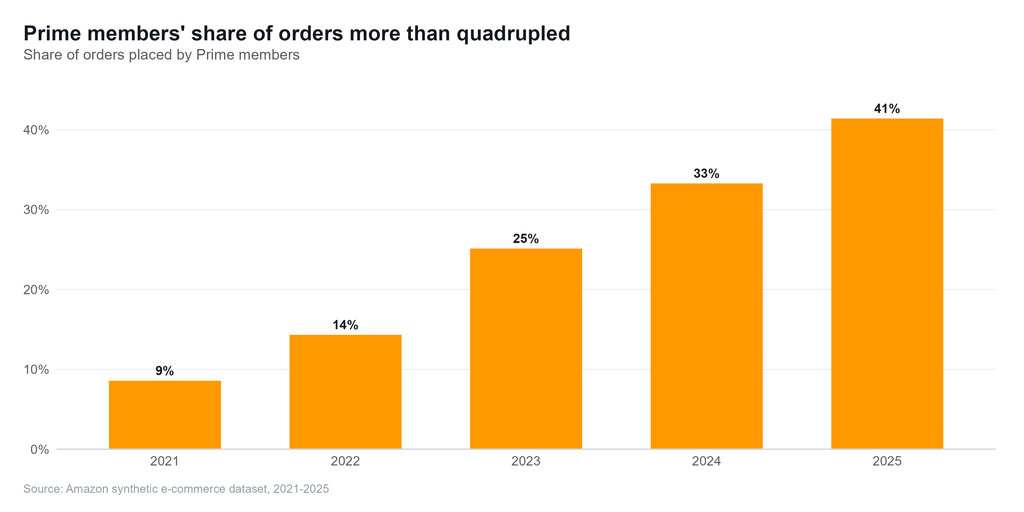

**Results.** Prime members placed 41% of orders in 2025, up from 9% in 2021. The jump started with the loyalty push in 2023. Prime orders are also 5.2% larger on average, so membership growth lifts both order frequency and basket size.

### RFM customer segments

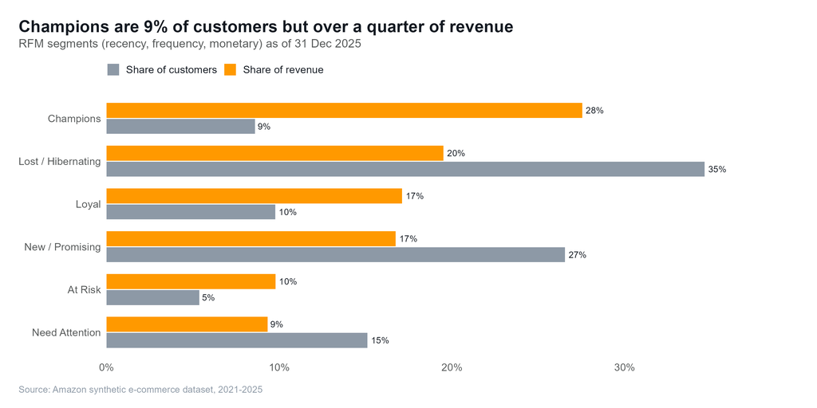

**Results.** Champions are 9% of customers but bring 28% of revenue. At Risk customers (5% of customers, 10% of revenue) used to buy often but have gone quiet, so they are the best target for win-back campaigns. Lost / Hibernating customers are the largest group (35%), mostly one-time buyers.

## 4. Marketing & channels

Where customers come from, what acquisition costs, and how campaigns perform.

Conversion rate

2.18%

+0.2 pp vs 2024

ROAS (revenue / ad spend)

13.0x

+8.9% vs 2024

Cost per new customer

$56.78

+6.6% vs 2024

Paid media spend

$416K

+4.9% vs 2024

Social media share

23.1%

+13.1 pp vs 2021

### Revenue share by channel

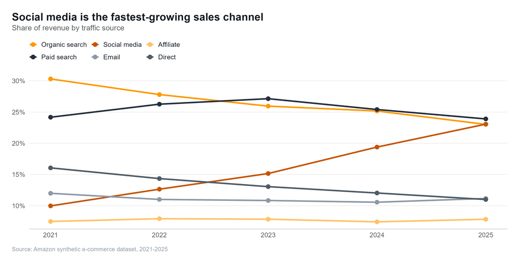

**Results.** Social media grew from 10.0% to 23.1% of revenue and now matches paid search and organic search. Organic search fell from 30.3% to 23.0%, so the business relies more on paid traffic than it did in 2021.

### Paid marketing efficiency

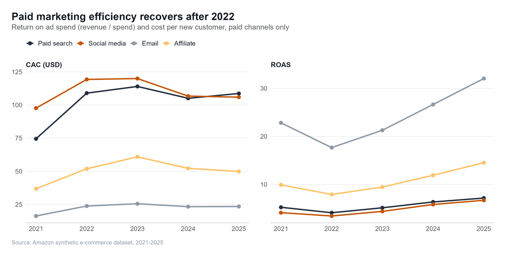

**Results.** Overall ROAS fell to 8.5x in 2022, when ad costs rose and conversion dropped, then recovered to 13.0x in 2025. Email is by far the most efficient channel (ROAS 32x). Paid search and social cost about $107 per new customer.

### Conversion rate

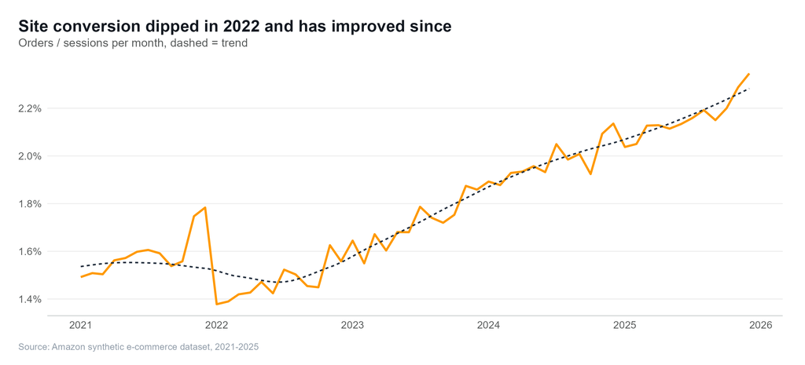

**Results.** Conversion hit its low of 1.38% in January 2022 and has improved steadily since, reaching 2.18% for 2025 as a whole. The rise in mobile app use and Prime membership both support higher conversion.

### Campaign return on investment

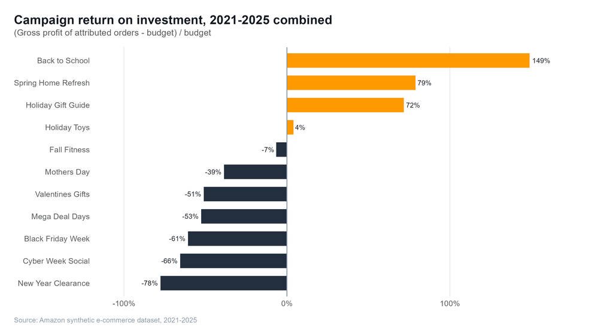

**Results.** Back to School is the most profitable campaign (ROI 149%). 7 of 11 campaign types lost money once discounts are counted. New Year Clearance performs worst (-78%). Large flagship events drive volume but give away margin through deep discounts, so their budgets and discount levels should be reviewed.

### Device mix

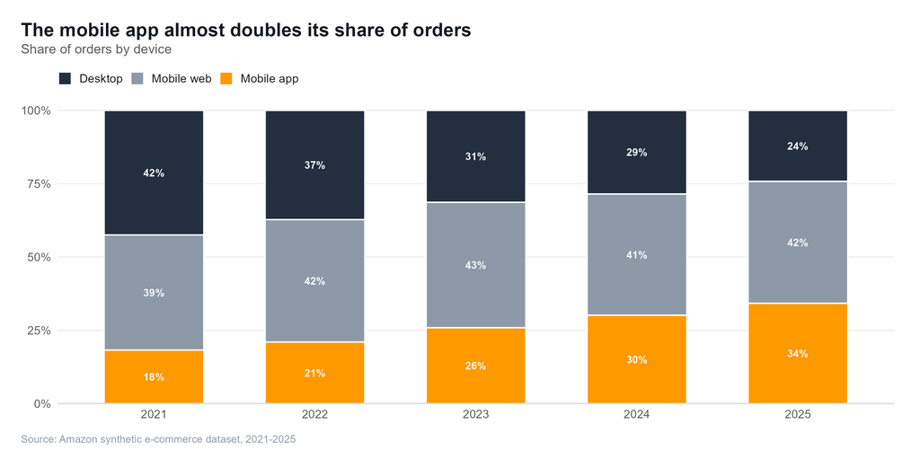

**Results.** The mobile app’s share of orders grew from 18% to 34%, while desktop declined every year. App-first features and offers now reach the largest group of shoppers.

### Payment methods

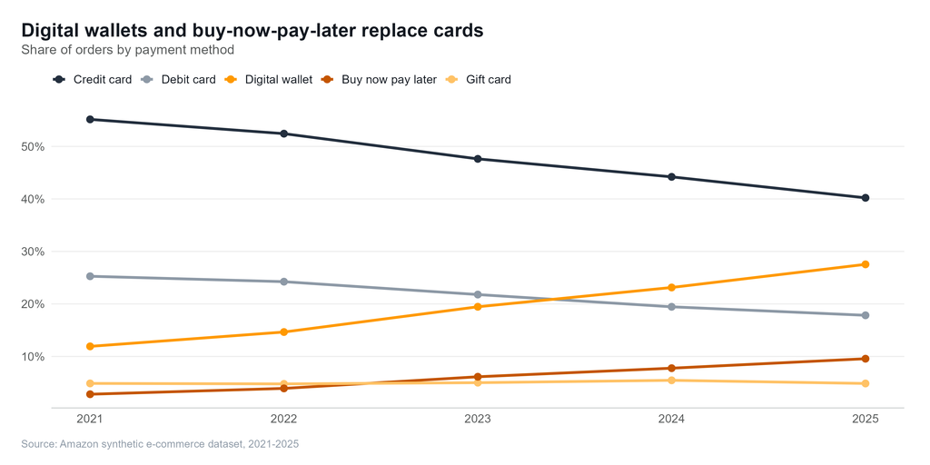

**Results.** Digital wallets and buy-now-pay-later together grew from 15% to 37% of orders. Credit cards are still the most used method but fell to 40%. Offering instalment payments matters more each year, especially for higher-priced electronics.

## 5. Fulfilment & quality

Delivery speed, stock availability, returns and customer ratings.

Avg delivery time

2.8 days

-11.5% vs 2024

Late deliveries

5.5%

-2.1 pp vs 2024

Return rate

6.2%

-1.0 pp vs 2024

Average rating

4.22 / 5

+0.07 vs 2024

Cancellation rate

2.7%

-0.4 pp vs 2024

### Delivery time

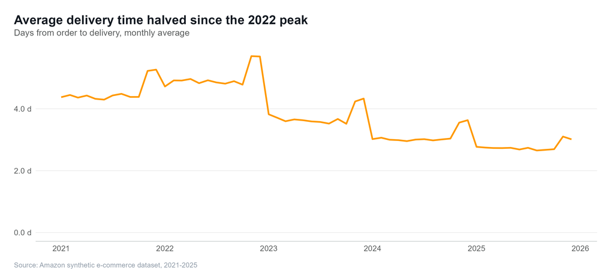

**Results.** Delivery took longest in 2022 (5.1 days on average). New warehouses in 2023-2024 and faster next-day shipping brought it down to 2.8 days in 2025. Every November-December still shows a small spike as volume peaks.

### Late deliveries by carrier

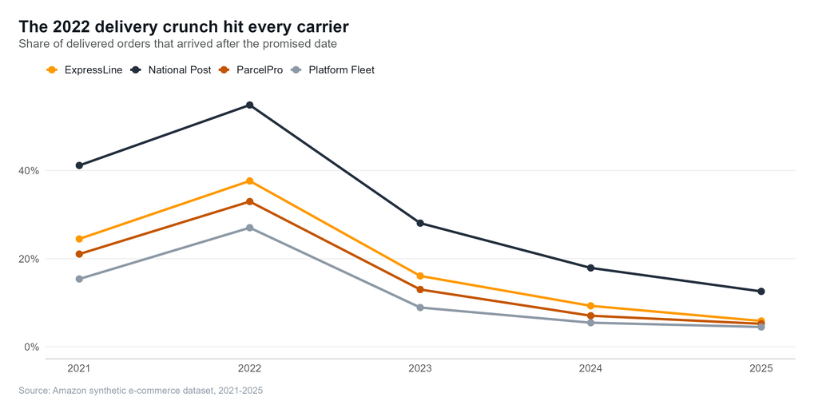

**Results.** In 2022, National Post delivered 55% of orders late, and the company-wide late rate reached 34%. By 2025 the late rate fell to 5.5%. Platform Fleet is now the most reliable carrier (4.5% late).

### Stockouts

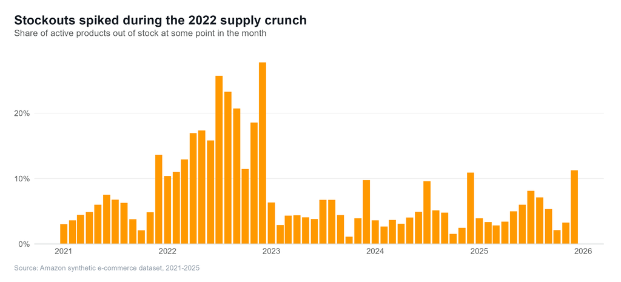

**Results.** Stockouts peaked in December 2022, when 28% of active products ran out at some point in the month. In 2025 the monthly average was 5.1%. Lost availability in 2022 is one reason that year missed its sales target.

### Return rate by category

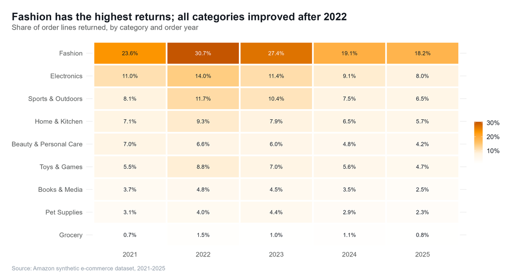

**Results.** Fashion has by far the highest return rate, peaking at 30.7% in 2022, mostly because of size and fit. The stricter return policy introduced in 2024 cut it to 18.2% in 2025, and the overall return rate fell from 11.8% to 6.2%.

### Return reasons

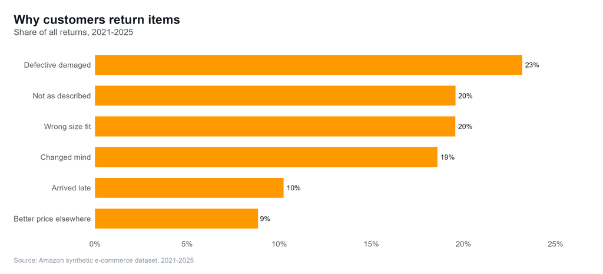

**Results.** The most common return reasons are defective or damaged (23%) and not as described (20%). Late arrival caused 10% of returns, and these were concentrated in 2022. Better product pages and quality checks would address the top two reasons.

### Customer ratings

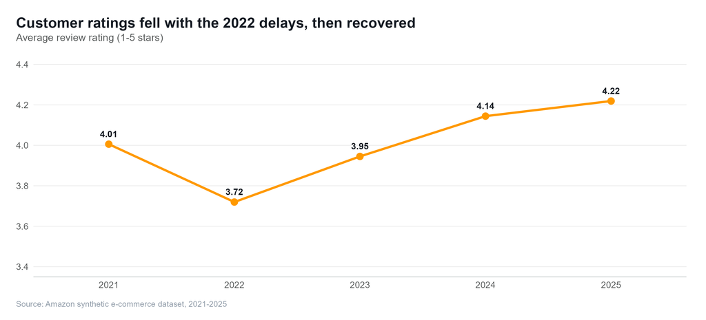

**Results.** The average rating dropped to 3.72 in 2022, when deliveries were slowest, and recovered to 4.22 in 2025, the best result in five years.

### Late delivery vs rating

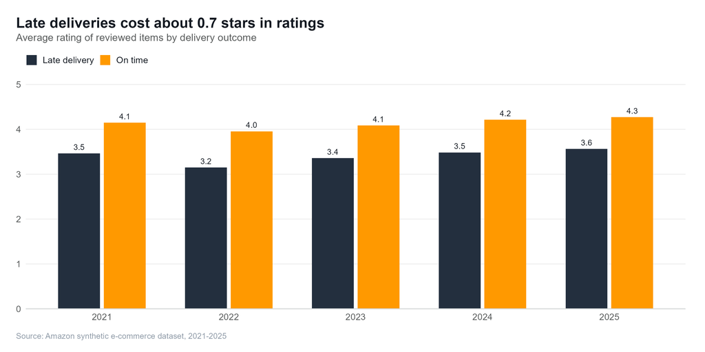

**Results.** Items delivered late are rated 0.7 stars lower than items delivered on time, on average across years (between 0.7 and 0.8 in each single year). Delivery speed directly affects how customers rate products, and so it affects future sales.

Data: synthetic Amazon-style e-commerce dataset, 2021-2025. Revenue = net item revenue of non-cancelled orders, before tax and shipping. Built with R, ggplot2 and R Markdown.